# Machine Learning: Course Project

```r
set.seed(77412)
library(caret, quietly=TRUE)
train <- read.csv("pml-training.csv")
```

# Summary

The data loaded above is a large set of 19,622 observations and 160 variables gathered from motion sensors attached to volunteers who were performing weight lifting exercises. Full details are [here](http://groupware.les.inf.puc-rio.br/har). The aim of this project is to build a model, using the random forest machine learning algorithm, that can predict the exercise being performed from the motion sensor data.

## Data Cleaning

There are many instances of the string “#DIV/0!” and of the empty string “” in the data. Let’s treat those as NA values.

```r
train[train==""]        <- NA
train[train=="#DIV/0!"] <- NA
```

Many of the columns are now almost completely filled with NAs. Make a function to measure this and then a histogram to see how the proportions of NAs are distributed.

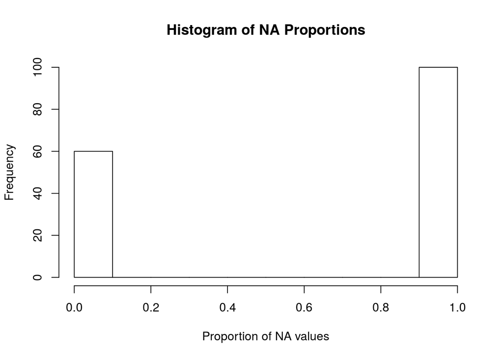

```r
na_prop <- function(x) sum(is.na(x))/length(x)
nas     <- sapply(train, na_prop)
hist(nas, xlab="Proportion of NA values", main="Histogram of NA Proportions")
```

**Figure 1** Histogram showing the proportion of NA values in each variable after data cleaning.

The histogram shows that the variables are divided into those with 90% or more NA values, and those with 10% or less - in fact inspection of the latter group shows that none of them have any NA values. Continue the study using only this group of variables as predictors, but save the names of the dropped variables so we can remove them from the test set also later on.

```r
droppedVars <- names(nas[nas>0.9])
train       <- train[names(nas[nas==0])]
```

## Feature Selection

The first seven variables remaining in `train` are the row numbers, the participants’ names, and various types of time-stamps and window variables. Inspection (not shown) of these indicates that most of them will not be of much value for prediction of the `classe` variable. Even if they were, the aim of the study is to use the motion sensor data for this purpose, so we will try to rely only on those variables and remove the first seven variables also. Again, we add the column names to our list.

```r
droppedVars <- c(droppedVars, names(train)[1:7])
train       <- train[-1:-7]
```

Lastly, check the remaining variables for low variance and for high correlations among themselves.

```r
nearZeroVar(train)                          # No low variance columns found.
```

```
## integer(0)
```

```r
corMat      <- cor(train[-dim(train)[2]])
hiCor       <- findCorrelation(corMat)      # 7 highly correlated columns found.
droppedVars <- c(droppedVars, names(train)[hiCor])
train       <- train[-hiCor]
```

Have a look at the data that we have left for unusual distributions, skew, etc.

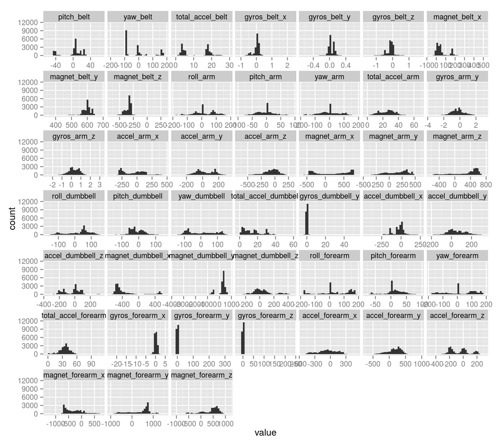

```r
library(reshape2)
hist_data <- melt(train[,-46])
ggplot(hist_data, aes(x=value)) +
    facet_wrap(~variable, scales="free_x") +
    geom_histogram()
```

**Figure 2** Histograms of remaining variables in the training set.

There seems to be a lot of skew in some variables (e.g. gryos_dumbbell_y) but if we use the random forest algorithm, our approach is not sensitive to skew and as there seem to be no other obvious problems we will not apply any transformations to the data.

## Data Slicing

Divide the training set in two - one set (70%) for training, and another (30%) for cross validation. Testing will be performed on a further data set which has not yet been loaded.

```r
divInd <- createDataPartition(y=train$classe, p=0.7, list=FALSE)
tset   <- train[ divInd,]
vset   <- train[-divInd,]
```

## Model Building

Now we are ready to carry out the training. After some initial experimentation (not shown here) we will use random forests.

```r
rfMod <- train(
    y=tset$classe, x=tset[,-46], allowParallel=TRUE,
    trControl = trainControl(method = "cv", number = 5)
)
rfMod$finalModel
```

```
##
## Call:
##  randomForest(x = x, y = y, mtry = param$mtry, allowParallel = TRUE)
##                Type of random forest: classification
##                      Number of trees: 500
## No. of variables tried at each split: 23
##
##         OOB estimate of  error rate: 0.65%
## Confusion matrix:
##      A    B    C    D    E class.error
## A 3900    4    1    0    1 0.001536098
## B   20 2632    6    0    0 0.009781791
## C    0   13 2377    6    0 0.007929883
## D    0    1   27 2221    3 0.013765542
## E    0    0    3    4 2518 0.002772277
```

## Out of Sample Error

The out of bag (OOB) error is very low at 0.6479%. It has been argued, for example [here](https://www.stat.berkeley.edu/~breiman/RandomForests/cc_home.htm#ooberr), that the OOB error provides an unbiased estimate of the test set error, while others, for example [here](http://www.scirp.org/journal/PaperDownload.aspx?paperID=8072), have argued that this is not always the case. We will take no position in this debate and will supply both the OOB and out of sample (OOS) estimates.

We estimate our out of sample error using cross-validation against the random subssample, `vset`, which we set aside earlier.

```r
predV   <- predict(rfMod, vset)
correct <- predV==vset$classe
oos     <- 1 - sum(correct)/length(correct)
table(predV, vset$classe)
```

```
##
## predV    A    B    C    D    E
##     A 1673   16    0    0    0
##     B    0 1117    6    0    0
##     C    0    4 1017   10    1
##     D    0    1    3  951    1
##     E    1    1    0    3 1080
```

This gives us a value of 0.7986% for our OOS error, which is reasonably close to the OOB error.

## Prediction against Test Set

Finally, load the test data, remove the same columns we removed from the training data, and then make our predictions to submit for the second part of the assignment.

```r
test  <- read.csv("pml-testing.csv")
test  <- test[ , -which(names(test) %in% droppedVars) ]
predT <- predict(rfMod, test[,-46])
```